# R Notebook

# Agglomerative and Divisive

# Dendogram

A diagram which shows where the clusters are. A visual representation of how the data can be clustered. Gives you the options of how many clusters you can have. Longest bar indicates biggest difference

# Distance Measures

The choice of distance measures will depend on the dataset and context. Classical - geometrical difference between points on a graph. e.g. Euclydian distance Correlation - how correlated are two data points.

# Heirarchical clustering in R

```r
library(tidyverse)
library(cluster)
library(factoextra)
library(dendextend)
```

```r
edu_data <- read_csv("data/education_usa.csv")
head(edu_data)
```

| X1 | high_school | community_college | college | grad_school |
| --- | --- | --- | --- | --- |
| Alabama | 13.2 | 236 | 58 | 21.2 |
| Alaska | 10.0 | 263 | 48 | 44.5 |
| Arizona | 8.1 | 294 | 80 | 31.0 |
| Arkansas | 8.8 | 190 | 50 | 19.5 |
| California | 9.0 | 276 | 91 | 40.6 |
| Colorado | 7.9 | 204 | 78 | 38.7 |

```r
dim(edu_data)
```

```
[1] 50  5
```

```r
class(edu_data)
```

```
[1] "spec_tbl_df" "tbl_df"      "tbl"         "data.frame"
```

```r
edu_data_scale <- edu_data %>%
              janitor::clean_names() %>%
              rename(state = x1) %>%
              mutate_if(is.numeric, scale)
edu_data_scale
```

| state | high_school | community_college | college | grad_school |
| --- | --- | --- | --- | --- |
| Alabama | 1.24256408 | 0.78283935 | -0.52090661 | -0.003416473 |
| Alaska | 0.50786248 | 1.10682252 | -1.21176419 | 2.484202941 |
| Arizona | 0.07163341 | 1.47880321 | 0.99898006 | 1.042878388 |
| Arkansas | 0.23234938 | 0.23086801 | -1.07359268 | -0.184916602 |
| California | 0.27826823 | 1.26281442 | 1.75892340 | 2.067820292 |
| Colorado | 0.02571456 | 0.39885929 | 0.86080854 | 1.864967207 |
| Connecticut | -1.03041900 | -0.72908214 | 0.79172279 | -1.081740768 |
| Delaware | -0.43347395 | 0.80683810 | 0.44629400 | -0.579946294 |
| Florida | 1.74767144 | 1.97077766 | 0.99898006 | 1.138966691 |
| Georgia | 2.20685994 | 0.48285493 | -0.38273510 | 0.487701523 |

[output cut: 40 more lines]

```r
edu_data_scale %>%
  as_tibble() %>%
  pivot_longer(-state,
               names_to = "type",
               values_to = "value") %>% #convert data to long format
  group_by(type)%>%
  summarise(mean = round(mean(value)),
            sd = sd(value))
```

| type | mean | sd |
| --- | --- | --- |
| college | 0 | 1 |
| community_college | 0 | 1 |
| grad_school | 0 | 1 |
| high_school | 0 | 1 |

# Calculate correlation distances

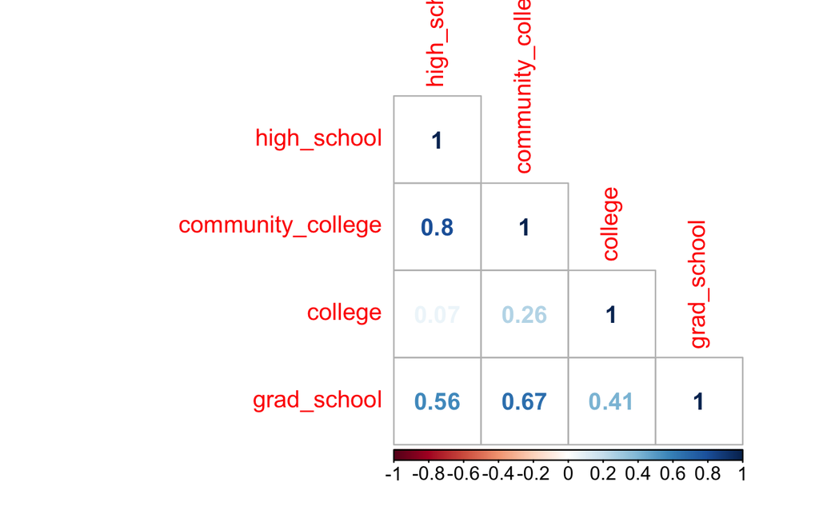

```r
library(corrplot)
# can't plot categories on a correlation plot (needs numbers only)
edu_numeric <- edu_data_scale %>%
  select(-state)
# create a correlation plot
corrplot(cor(edu_numeric), method = "number", type = "lower")
```